# WGCNA_tutorial

## WGCNA tutorial for Sprialbase VLM 11/18/21

This tutorial is intented to be a basic introduction to using WGCNA for RNAseq datasets. For this we will use transcriptomic data from the startlet sea anemone *Nematostella vectnensis* spanning the first seven days of development [(Warner et al. 2018)](https://pubmed.ncbi.nlm.nih.gov/29739837/). This is not an ideal dataset, the sampling is sparse, every 24 hours for 7 days in duplicate. This sampling is more typical of a first approach used by embryologists to characterize and emerging model system. An ideal sampling design would be a very dense sampling of a discrete biological process (e.g. the timepoints surrounging a morphogenetic event). In any experimental design, WGCNA performs best with 16 samples or more. Fewer than this and identifying modules becomes very challenging.

First let’s read in the data.These data have already been quantified against a transcriptome using bowtie2 and RSEM, normalized with EdgeR, and each transcript count was summed in term of each gene model from the draft genome. The only transformation we will do here is a log2 transform.

```r
warner_data <- read.table(url("https://raw.githubusercontent.com/ScientistJake/Spiralbase_VLM_tutorial/main/data/Warner_normalized_cpm.txt"), header = T, quote = "")
warner_data_Log2 = log(warner_data+1,2)
```

Next we will explore the data using a simple PCA. This will give us a general idea of the structure of our data.

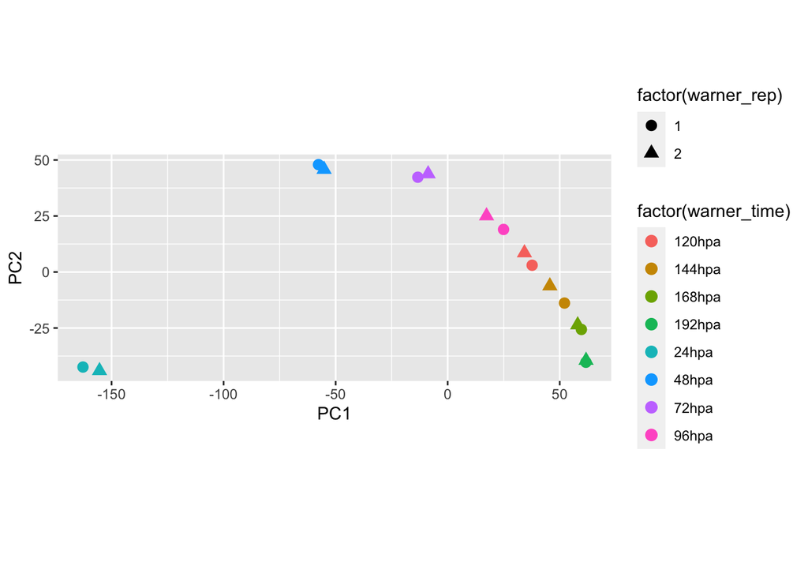

```r
library(ggplot2)
library(tidyverse)

warner_rep <- factor(c(1,2,1,2,1,2,1,2,1,2,1,2,1,2,1,2))
warner_time <- factor(c("24hpa","24hpa","48hpa","48hpa","72hpa","72hpa","96hpa","96hpa","120hpa","120hpa","144hpa","144hpa","168hpa","168hpa","192hpa","192hpa"))

warner_PCA_data <- warner_data_Log2 %>%
  t() %>% #this puts samples as rows, genes as columns
  as.data.frame() %>%
  prcomp()

warner_scores_to_plot <- as.data.frame(warner_PCA_data$x)
ggplot(data = warner_scores_to_plot,
       aes(x = PC1, y = PC2,
           label = rownames(warner_scores_to_plot),
           colour=factor(warner_time),
           shape=factor(warner_rep)
           )
       ) +
  geom_point(size=3) +
  scale_fill_hue(l=40) +
  coord_fixed(ratio=1, xlim=range(warner_scores_to_plot$PC1), ylim=range(warner_scores_to_plot$PC2))
```

In this plot we can see there’s a lot of variation in the first two days (as is expected), while later at timepoints the transcriptomic differences become less pronounced. We’ll keep this in mind since this means we will likely observe very large modules that correlate to 24hpf and 48hpf that will be difficult to tease out.

Let’s proceed with WGCNA below. We’re going to read in the data and again apply a log2 transformation. It is important NOT to filter the data by differential expression or variance beforehand. Doing so will result in a few very large modules that correlate to your filtering criteria. Don’t worry, all of the low variance genes will fall into the background (grey module). The first step is to read in the data and choose the soft power. Soft-thresholding power is a key parameter in scale free networks such as WGCNA. When using timeseries data it’s normal to not have an R^2 that exceeds 0.90. This is because time series data, or perturbation data for that matter, include strong drivers of variance. In these cases, and especially for datasets that span long timeseries, you can try choosing a soft power that crosses a lower threshold like 0.80 or pick a generic soft power [as outlined in faq 6 here](https://horvath.genetics.ucla.edu/html/CoexpressionNetwork/Rpackages/WGCNA/faq.html).

```r
rm(list = ls())
gc()
```

```
##           used (Mb) gc trigger  (Mb) limit (Mb) max used  (Mb)
## Ncells 1073492 57.4    2085682 111.4         NA  2085682 111.4
## Vcells 1898627 14.5    8388608  64.0      32768  5743361  43.9
```

```r
library(WGCNA)
library(tidyverse)

warner_WGNCA_data <- read.table(url("https://raw.githubusercontent.com/ScientistJake/Spiralbase_VLM_tutorial/main/data/Warner_normalized_cpm.txt"), header = T, quote = "") %>%
  mutate_all(function(x) log(x+1,2)) %>%
  t()

powers = c(c(1:10), seq(from = 12, to=40, by=2))
disableWGCNAThreads()
sft = pickSoftThreshold(warner_WGNCA_data, powerVector = powers, verbose = 5, networkType = "signed")
```

```
## pickSoftThreshold: will use block size 2469.
##  pickSoftThreshold: calculating connectivity for given powers...
##    ..working on genes 1 through 2469 of 18118
##    ..working on genes 2470 through 4938 of 18118
##    ..working on genes 4939 through 7407 of 18118
##    ..working on genes 7408 through 9876 of 18118
##    ..working on genes 9877 through 12345 of 18118
##    ..working on genes 12346 through 14814 of 18118
##    ..working on genes 14815 through 17283 of 18118
##    ..working on genes 17284 through 18118 of 18118
##    Power SFT.R.sq   slope truncated.R.sq mean.k. median.k. max.k.
## 1      1  0.10500  6.9600       -0.09630    9070      9090   9430
## 2      2  0.61900  3.0500        0.73100    6200      6370   7350
## 3      3  0.69500  1.5400        0.63500    4760      5040   6300
## 4      4  0.81700  0.9910        0.77200    3870      4160   5580
## 5      5  0.77500  0.6440        0.76500    3270      3530   5030
## 6      6  0.67400  0.4170        0.73900    2820      3040   4590
## 7      7  0.47700  0.2330        0.60700    2470      2650   4300
## 8      8  0.13600  0.0915        0.26900    2200      2330   4060
## 9      9  0.00762 -0.0204       -0.00852    1970      2060   3850
## 10    10  0.17700 -0.1100        0.06770    1790      1840   3660
## 11    12  0.51000 -0.2460        0.38800    1490      1480   3350
## 12    14  0.65500 -0.3470        0.55800    1270      1220   3090
## 13    16  0.72400 -0.4290        0.64700    1100      1010   2870
## 14    18  0.75800 -0.4970        0.70500     966       850   2680
## 15    20  0.77800 -0.5520        0.74400     856       720   2520
## 16    22  0.79900 -0.5970        0.78200     764       612   2370
## 17    24  0.81000 -0.6400        0.80800     687       527   2240
## 18    26  0.81400 -0.6780        0.82500     622       455   2130
## 19    28  0.81900 -0.7090        0.84100     566       395   2020
## 20    30  0.82500 -0.7410        0.85600     517       344   1930
## 21    32  0.82500 -0.7700        0.86600     475       302   1840
## 22    34  0.82800 -0.7950        0.87700     437       267   1760
## 23    36  0.83400 -0.8180        0.88700     404       236   1690
## 24    38  0.83700 -0.8390        0.89400     375       209   1620
## 25    40  0.84100 -0.8590        0.90300     349       185   1550
```

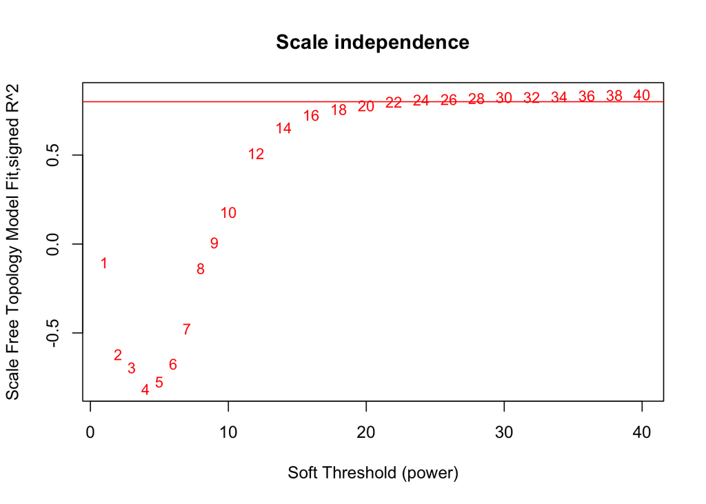

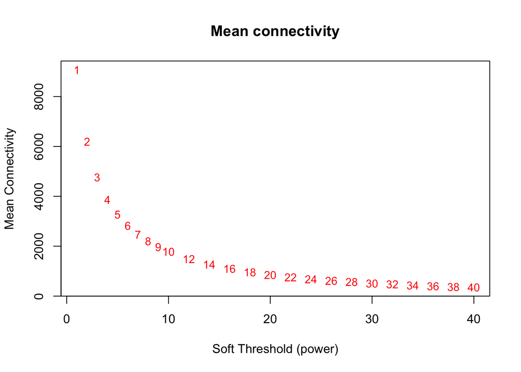

```r
{cex1 = 0.9;
plot(sft$fitIndices[,1], -sign(sft$fitIndices[,3])*sft$fitIndices[,2],
     xlab="Soft Threshold (power)",ylab="Scale Free Topology Model Fit,signed R^2",type="n",
     main = paste("Scale independence"));
text(sft$fitIndices[,1], -sign(sft$fitIndices[,3])*sft$fitIndices[,2],
     labels=powers,cex=cex1,col="red");
  # this line corresponds to using an R^2 cut-off of h
abline(h=0.80,col="red")
plot(sft$fitIndices[,1], sft$fitIndices[,5],
     xlab="Soft Threshold (power)",ylab="Mean Connectivity", type="n",
     main = paste("Mean connectivity"))
text(sft$fitIndices[,1], sft$fitIndices[,5], labels=powers, cex=cex1,col="red")
}
```

You can see that the model fit plateus at around 20 so we’ll start with this as our soft-thresholding power.

```r
softPower = 20 # (Read WGCNA tutorial to learn how to pick your power)
rankExpr = rank(colMeans(warner_WGNCA_data))
rankConn = rank(softConnectivity((warner_WGNCA_data),type="signed",power=softPower))

enableWGCNAThreads()
library(flashClust)

adjacency = adjacency((warner_WGNCA_data),power=softPower,type="signed");
diag(adjacency)=0
Degree <- rowSums(adjacency)

Degree=Degree/max(Degree); gc()
dissTOM = 1-TOMsimilarity(adjacency, TOMType="signed")
geneTree = flashClust(as.dist(dissTOM), method="average")
```

```r
mColor=NULL
for (ds in 0:3){
  tree = cutreeHybrid(dendro = geneTree, pamStage=F, minClusterSize = (30-3*ds), deepSplit = ds, distM = dissTOM)
  mColor=cbind(mColor,labels2colors(tree$labels)); }
```

```
##  ..cutHeight not given, setting it to 0.993  ===>  99% of the (truncated) height range in dendro.
##  ..done.
##  ..cutHeight not given, setting it to 0.993  ===>  99% of the (truncated) height range in dendro.
##  ..done.
##  ..cutHeight not given, setting it to 0.993  ===>  99% of the (truncated) height range in dendro.
##  ..done.
##  ..cutHeight not given, setting it to 0.993  ===>  99% of the (truncated) height range in dendro.
##  ..done.
```

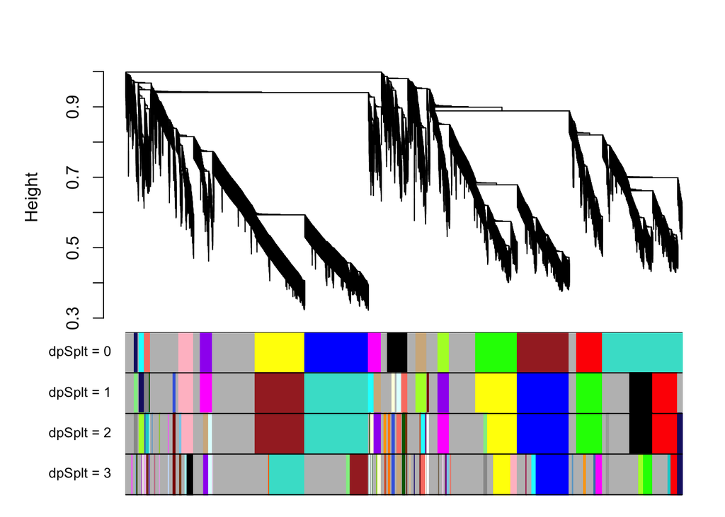

```r
plotDendroAndColors(geneTree, mColor, paste("dpSplt =",0:3), main = "",dendroLabels=FALSE);
```

Looking at this tree the first thing that pops out is the size of the branches and clusters which are very large. This is typical of embryonic timeseries data since there are massive differences between each timepoint. Here, I would recommend a deepsplit of 1 since there appears to be some subsctrucutre to the three branches in the middle and results in smaller modules as opposed to dewpsplit 0. As stated above, I would try this several ways.

```r
#pick a module deep split
modules = mColor[,2]
dynamicColors= labels2colors(modules)

#print the module sizes
table(modules)
```

```
## modules
##        black         blue        brown         cyan    darkgreen
##          747         1694         1611          181           43
##      darkred        green  greenyellow         grey       grey60
##           79          847          352         5829          146
##    lightcyan   lightgreen  lightyellow      magenta midnightblue
##          148          132          106          398          169
##         pink       purple          red    royalblue       salmon
##          483          371          813          102          203
##          tan    turquoise       yellow
##          236         2072         1356
```

You can see from the results above that the modules are quite large but with the deeplsplit we can recover smaller more managable modules. `grey` is reserved for unassigned so a third of the genes here aren’t in any module.

Next we’ll extract [eigengenes](https://en.wiktionary.org/wiki/eigengene) which summarize the expression of each module. Here, we’re only plotting the eigengenes for one module, ‘cyan’, but I included a commented section of code below that which will loop through the modules and save each plot into a directory. I also include the replicate information in my plots to see if one replicate is a significant driver of a particular module.

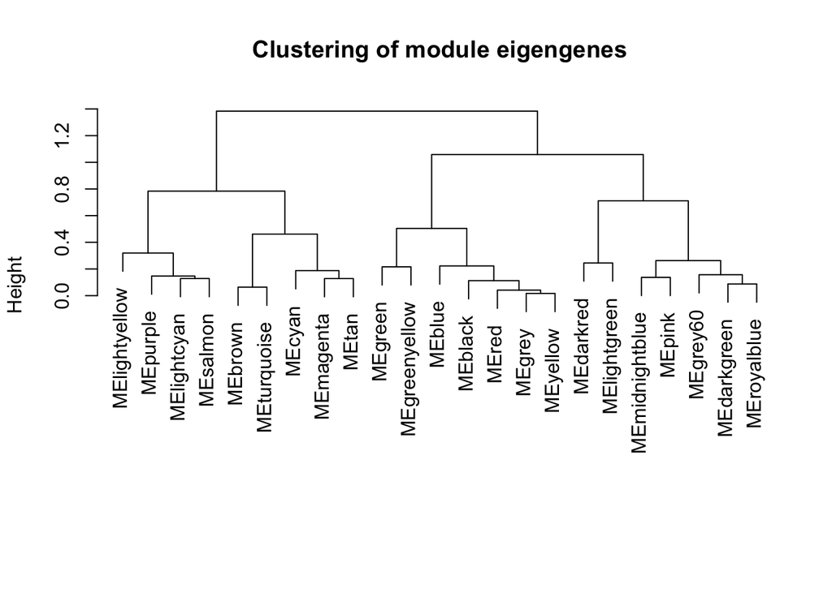

```r
PCs = moduleEigengenes((warner_WGNCA_data), colors=modules)
ME  = PCs$eigengenes
MEDiss= 1-cor(ME)
METree= flashClust(as.dist(MEDiss), method= "average")
MEs= orderMEs(ME)

plot(METree, main= "Clustering of module eigengenes", xlab= "", sub= "")
```

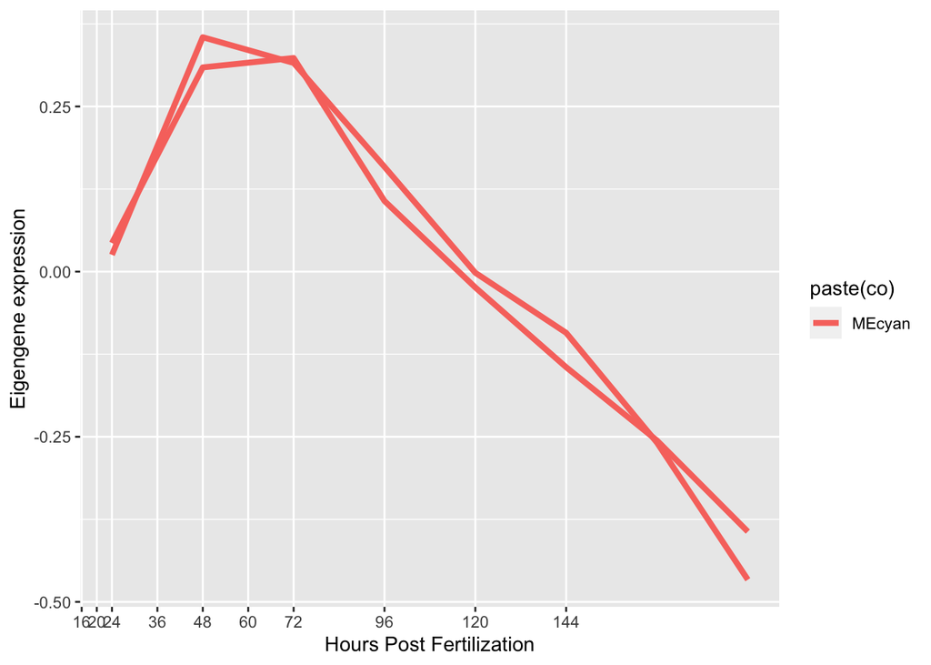

```r
## optional merge
## run this if you have overly redundant modules

#MEDissThres= 0.15
#merge= mergeCloseModules(warner_WGNCA_data, modules, cutHeight= MEDissThres, verbose =3)
#mergedColors= merge$colors

library(reshape)
ME_plot <- as.data.frame(t(MEs))
colnames(ME_plot) = c(24,24,48,48,72,72,96,96,120,120,144,144,168,168,192,192)

library(ggplot2)
row.names(ME_plot) <- rownames(ME_plot)
ME_plotM <- melt(as.matrix(ME_plot), id.vars="row.names", value.name="value")

co = c("MEcyan")

ME_plot_color <- ME_plotM[ME_plotM$X1 == paste(co),]
  group <- c(1,2,1,2,1,2,1,2,1,2,1,2,1,2,1,2)

  p <-  ggplot(ME_plot_color, aes(x=as.numeric(as.character(ME_plot_color$X2)), y=value, colour=paste(co), group = group)) +
    geom_line(size =1.5) +
    scale_x_continuous(minor_breaks = NULL, breaks=c(0,2,4,8,12,16,20,24,36,48,60,72,96,120,144)) +
    ylab("Eigengene expression") +
    xlab("Hours Post Fertilization")

  print(p)
```

```r
# for(co in rownames(ME_plot)){
#   ME_plot_color <- ME_plotM[ME_plotM$X1 == paste(co),]
#   group <- c(1,2,3,1,2,3,1,2,3,1,2,3,1,2,3,1,2,3,1,2,3,1,2,3,1,2,3,1,2,3,1,2,3,1,2,3,1,2,3,1,2,3,1,2,3)
#
#   p <-  ggplot(ME_plot_color, aes(x=as.numeric(as.character(ME_plot_color$X2)), y=value, colour=paste(co), group = group)) +
#     geom_line(size =1.5) +
#     scale_x_continuous(minor_breaks = NULL, breaks=c(0,2,4,8,12,16,20,24,36,48,60,72,96,120,144)) +
#     ylab("Eigengene expression") +
#     xlab("Hours Post Fertilization")
#
#   file = paste("plots/ME_", co, ".pdf", sep="")
#   pdf(file = file, width = 8, height = 6)
#   print(p)
#   dev.off()
# }
```

From the clustering we can see that our modules are fairly well separated. This kind of clustering also lets us gauge module similarity in the event we want to merge close modules or when we explore the data in more detail notice that certain modules are too similar.

Next we can make a heatmap that correlates the modules with traits/ phenotypes/ geneotypes / whatever. In this dataset the only variable we have is time so that’s what our correlation will be based on. This is where you would include data for knockdowns as well.

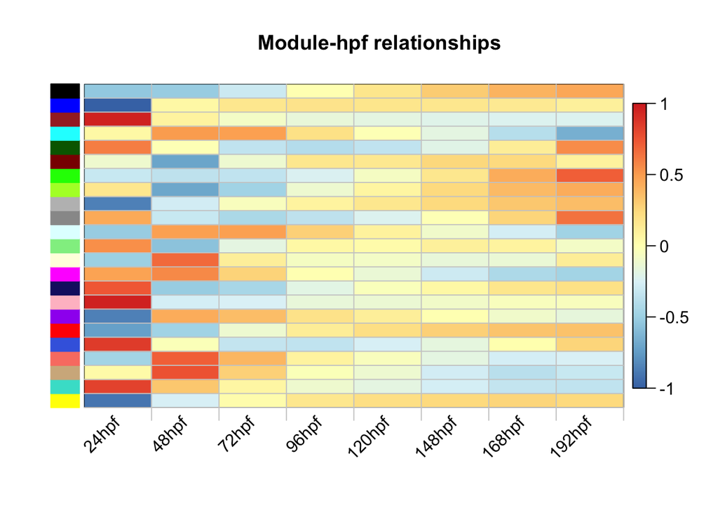

```r
traits <- read.table(url("https://raw.githubusercontent.com/ScientistJake/Spiralbase_VLM_tutorial/main/data/warner_traits.txt"), sep='\t', header=T, quote="",row.names=1)

nGenes = ncol(warner_WGNCA_data)
nSamples = nrow(warner_WGNCA_data)
moduleTraitCor = cor(ME, traits, use = "p");
moduleTraitPvalue = corPvalueStudent(moduleTraitCor, nSamples)

textMatrix = paste(signif(moduleTraitCor, 2), "\n(",signif(moduleTraitPvalue, 1), ")", sep = "");
dim(textMatrix) = dim(moduleTraitCor)
library('viridis')
library(RColorBrewer)
colors = colorRampPalette(rev(brewer.pal(n = 9, name ="RdYlBu")))(200)

labeledHeatmap(Matrix = moduleTraitCor,
  xLabels = c("24hpf","48hpf","72hpf","96hpf","120hpf","148hpf","168hpf","192hpf"),
  yLabels = names(ME),
  colorLabels = FALSE,
  colors = colors,
  #textMatrix = textMatrix,
  setStdMargins = F,
  cex.text = 0.5,
  zlim = c(-1,1),
  verticalSeparator.x = 1:dim(moduleTraitCor)[2],
  verticalSeparator.col="grey80",
  horizontalSeparator.y = 1:dim(moduleTraitCor)[1],
  horizontalSeparator.col="grey80",
  main = paste("Module-hpf relationships")
  )
```

As you can see, most of our modules have a strong correlation/ anti-correlation with the first time point. This is to be expected as it is the most distinct in terms of gene expression. We do observe some other interesting modules however like those that correlate to 48hpf or the later developmental timepoints.

If our modules are discrete enough, we can calculate the intra-module connectivity of each gene. This will allow us to identify hub genes aka genes with high connectivity to many other genes within a module. In theory, these genes are important to the function of the module as a whole. In application this theory typically holds up rather well with hub genes representing key markers / differentiation factors / gene products that are activated in a cell under certain conditions *assuming that your modules are not too large and correlate to discrete biological events*.

In datasets like this one, it is futile to try and identify hub genes for the large modules. There will simply be too many genes with very high connectivity. So if you are most interested in the modules activated at 24hpf I would recommend resampling at a tighter time interval around this timepoint. Here, we’ll exam the cyan module since it is relatively small and has an interesting expression pattern peaking at 48hpf. Below is some code that will export the connectivity data in a format that is directly accepted by [visant](http://www.visantnet.org/visantnet.html). This will make two tables, one that includes connections over a connection strength of 0.05 to exlcude weak connections and another that includes just the top 250 genes. You can modify these or add additional exports with different cutoffs if your lists are too small/large. I also included a commented code set to loop this and export tables for all modules.

```r
TOM = TOMsimilarity(adjacency, TOMType="signed")

#we need some annotations otherwise we'll be looking at useless gene IDs
annotations = read.table(url("https://raw.githubusercontent.com/ScientistJake/Spiralbase_VLM_tutorial/main/data/Nemve1_annotated_uprotnames.txt"), sep='\t', header=T, quote="")

module = "cyan";
probes = colnames(warner_WGNCA_data)
  inModule = (modules==module);
  modProbes = probes[inModule];

  # Select the corresponding Topological Overlap
  modTOM = TOM[inModule, inModule];
  dimnames(modTOM) = list(modProbes, modProbes)

  # Export the network into an edge list file VisANT can read
  vis = exportNetworkToVisANT(modTOM,file = paste("data/VisANTInput-", module, "_0.05.txt", sep=""),
    weighted = TRUE,
    threshold = 0.05,
    probeToGene = data.frame(annotations$ContigName, annotations$Description)
    )
  write.table(vis, file= paste("data/VisANTInput-", module, "_0.05.txt", sep=""),sep='\t',row.names = F,quote=F)

  #now export just the top 250 connections
  nTop = 250;
  IMConn = softConnectivity(warner_WGNCA_data[, modProbes]);
  top = (rank(-IMConn) <= nTop)
  vis = exportNetworkToVisANT(modTOM[top, top],file = paste("data/VisANTInput-", module, "-top",nTop,".txt", sep=""),
    weighted = TRUE,
    threshold = 0,
    probeToGene = data.frame(annotations$ContigName, annotations$Description)
  )
  write.table(vis, file=paste("data/VisANTInput-", module, "-top",nTop,".txt", sep=""),sep='\t',row.names = F,quote=F)

# #use this loop to bulk generate visant tables:
#
# for (module in unique(module_colors)[which(unique(module_colors) != "grey")]){
#   # Select module probes
#   probes = colnames(warner_WGNCA_data)
#   inModule = (modules==module);
#   modProbes = probes[inModule];
#
#   # Select the corresponding Topological Overlap
#   modTOM = TOM[inModule, inModule];
#   dimnames(modTOM) = list(modProbes, modProbes)
#
#   # Export the network into an edge list file VisANT can read
#   vis = exportNetworkToVisANT(modTOM,file = paste("data/VisANTInput-", module, "_0.05.txt", sep=""),
#     weighted = TRUE,
#     threshold = 0.05,
#     probeToGene = data.frame(annotations$ContigName, annotations$Description)
#   )
#   write.table(vis, file= paste("data/VisANTInput-", module, "_0.05.txt", sep=""),sep='\t',row.names = F,quote=F)
#
#   nTop = 250;
#   IMConn = softConnectivity(warner_WGNCA_data[, modProbes]);
#   top = (rank(-IMConn) <= nTop)
#   vis = exportNetworkToVisANT(modTOM[top, top],file = paste("data/VisANTInput-", module, "-top",nTop,".txt", sep=""),
#     weighted = TRUE,
#     threshold = 0,
#     probeToGene = data.frame(annotations$ContigName, annotations$Description)
#   )
#   write.table(vis, file=paste("data/VisANTInput-", module, "-top",nTop,".txt", sep=""),sep='\t',row.names = F,quote=F)
#
# }
```

Occasionally these tables need some massaging before getting them into visant. If your gene IDs have unallowed characters like commas, spaces, or whatever you can replace those with underscores in excel or an editor. For huge lists, I also would sort the data by connection strength (last column) and take the top 5,000-10,000 connections. Once in visant, you can further threshold by connection strength and widdle it down to the few ndoes with highest connections. Again, this works best when you have small, discrete modules that correlate highly to a process, treatment, or timepoint. If they’re too large they will get clogged up with genes that maintain basic cellular functions and that aren’t strongly correlated to your process of interest.

In these data, most of the modules will be difficult to analyze using visant since the sampling is so sparse. The cyan module was small enough that some interesting factors could be identified:

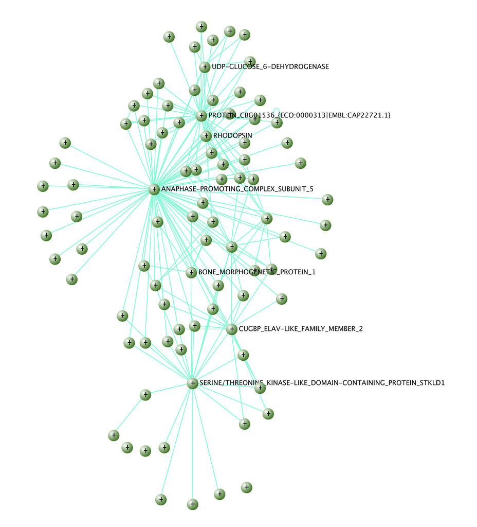

Trust your biologist eye to figure out what modules are doing. Alterantively, you can use module identities to subset your data and run GO-term enrichments. This will let you pick out biologically relevant modules and focus your efforts! Good luck! Please don’t hesitate to reach out at warnerj@uncw.edu with any questions!